# Mth3010A - Mathematical Finance Midsem

**Solve all problems while demonstrating each step clearly. The Exam is worth a total of 20 points**

Name: Chesia Anyika

ID: 665567

## Question 1:

**Define sample space, measurable space and probability measure and give examples in each case. Explain their significance in mathematical finance (3pts)**

### 1.1. Sample Space ($\Omega$):

**Definition** The sample space is the set of all possible outcomes of a random experiment. It is denoted by $\Omega$. As an example, for a coin toss, the sample space is $\Omega = \{ \text{Heads}, \text{Tails}\}$.

**Significance:** The sample space represents all possible states or outcomes of a financial system. For instance, the sample space could include all possible future prices of a stock.

### 1.2. Measurable Space ($\Omega, \mathcal{F}$):

**Definition**: A measurable space defines a collection of sets to which measures or probabilities can be assigned. It is a pair $\Omega, \mathcal{F}$ where $\Omega$ is the sample space and $\mathcal{F}$ is a $\sigma \text{-algebra}$ of subsets of $\Omega$. The $\sigma \text{-algebra}$ $[\mathcal{F}]$ is a collection of subsets of $\Omega$ that includes the sample space itself, is closed under complementation, and is closed under countable unions.

As an example, for a coin toss, $\Omega = \{ \text{Heads}, \text{Tails} \}$, and a possible $\sigma \text{-algebra}$ could be $ \mathcal{F} = \{ \emptyset, \{ \text{Heads} \}, \{ \text{Tails} \}, \{ \text{Heads}, \text{Tails} \} \}$.

**Significance:** The σ-algebra $\mathcal{F}$ represents the collection of events (subsets of the sample space) for which we can assign probabilities. This allows for the formalization of which events can be measured and analyzed.

### 1.3 Probability Measure (( P )):

**Definition**: A probability measure is a function $P: \mathcal{F} \rightarrow [0, 1]$ that assigns a probability to each event in the σ-algebra $\mathcal{F}$. It satisfies three axioms:

1. **Non-negativity**: $P(A) \geq 0$ for all $A \in \mathcal{F}$.
2. **Normalization**: $P(\Omega) = 1$.
3. **Countable Additivity**: If $\{A_i\}$ is a countable collection of disjoint sets in $\mathcal{F}$, then $P\left( \bigcup_{i=1}^{\infty} A_i \right) = \sum_{i=1}^{\infty} P(A_i)$.

As an example, For a fair coin toss, the probability measure can be defined as $P_{\text{Heads}\}} = 0.5$ and $P_{\text{Tails}\}} = 0.5$.

**Significance:** Assigns probabilities to events in the σ-algebra $\mathcal{F}$. This is essential for pricing derivatives, assessing risk, and making decisions under uncertainty. For example, in option pricing models like the Black-Scholes model, the probability measure is used to determine the likelihood of different price paths of the underlying asset.

## Question 2

**Completely characterize a normal distribution. Explain in details the significance of a normal distribution in the pricing of options (3pts)**

### 2.1 Characterisation of a Normal Distribution

#### 2.1.1 Definition and Mathematical Representation

A normal distribution, also known as the Gaussian distribution, is a continuous probability distribution characterized by its mean (µ) and variance (σ²). The probability density function (PDF) of the normal distribution is given by:

$f(x) = \frac{1}{\sqrt{2\pi\sigma^2}} \exp\left(-\frac{(x - \mu)^2}{2\sigma^2}\right)$

where:

- $\mu$ is the mean of the distribution.
- $\sigma^2$ is the variance of the distribution.
- $\sigma$ is the standard deviation, which is the square root of the variance.

#### 2.1.2 Properties

1. **Mean ($\mu$)**: The central point around which the data is symmetrically distributed. It represents the expected value of the distribution: $\mu = E[X]$
2. **Variance ($\sigma^2$)**: Measures the spread or dispersion of the distribution. It quantifies how much the values of the distribution deviate from the mean: $\sigma^2 = \text{Var}(X) = E[(X - \mu)^2]$
3. **Standard Deviation ($\sigma $)**: The square root of the variance: $\sigma = \sqrt{\sigma^2}$
4. **Symmetry**: The normal distribution is symmetric about its mean $\mu$.
5. **Bell-Shaped Curve**: The PDF forms a bell-shaped curve centered at the mean $\mu$.

#### 2.1.3 Examples in Mathematical Finance

1. **Asset Returns**: The returns on financial assets, such as stocks, are often assumed to be normally distributed. If the return $R$ of an asset is normally distributed with mean $\mu$ and variance $\sigma^2 $, it can be represented as: $R \sim N(\mu, \sigma^2)$
2. **Black-Scholes Model**: The Black-Scholes model, a cornerstone of modern financial theory, assumes that the logarithm of stock prices follows a normal distribution. If $S_t$ represents the stock price at time $t$, then: $\log(S_t) \sim N(\mu, \sigma^2)$ This assumption leads to the Black-Scholes formula for pricing European options.
3. **Value at Risk (VaR)**: VaR is a measure of the potential loss in value of a portfolio over a defined period for a given confidence interval. Assuming the returns are normally distributed, VaR can be calculated using the mean and standard deviation of the portfolio returns. For a confidence level $\alpha$: $\text{VaR}_\alpha = \mu + z_\alpha \sigma$ where $z_\alpha$ is the quantile of the standard normal distribution corresponding to the confidence level $\alpha$.

### 2.2 Significance in Option Pricing

The normal distribution plays a crucial role in the pricing of options, particularly through the Black-Scholes model. The model assumes that the log-returns of the underlying asset are normally distributed. This assumption simplifies the complex task of modeling the price movements of the underlying asset, allowing for the derivation of a closed-form solution for the price of European options.

1. **Risk Neutral Valuation**: The normal distribution allows for the use of risk-neutral valuation, where the expected return of the underlying asset in the risk-neutral world is the risk-free rate. This simplifies the valuation of options by enabling the use of discounted expected payoffs.
2. **Delta Hedging**: The normal distribution assumption allows for the calculation of the Greeks (sensitivities of the option price to various factors), particularly delta, which is used for hedging strategies to manage the risk of option portfolios.
3. **Volatility Estimation**: The standard deviation $\sigma$ in the normal distribution is directly related to the volatility of the underlying asset, which is a key input in the Black-Scholes model. Accurate estimation of volatility is crucial for option pricing and risk management.

In summary, the normal distribution is foundational in mathematical finance, providing a framework for modeling asset returns, deriving option pricing formulas, and implementing risk management strategies. .

## Question 3

**Simulate paths of Brownian motion and visualize them in Python. (choose your own parameters) (4pts)**

Suppose ${X(t), t \geq 0}$ is a Brownian motion process, with drift parameter 0 and diffusion parameter $\sigma^2$ where $\sigma = 0.5, 1, 1.7$, obtain the realization, when it is observed for the interval [0, 10]

First, I imported the necessary libraries to simulate this process and specified my parameters.

```python
import numpy as np
import matplotlib.pyplot as plt

# Parameters
T = 10  # total time
N = 500  # number of time steps
dt = T/N  # time step size
t = np.linspace(0, T, N+1)  # time array

# Standard deviations for Brownian motion
sigma1 = 0.5
sigma2 = 1.0
sigma3 = 1.7
```

I then simulated the brownian paths as follows:

```python
# Initialize arrays for the Brownian paths
W1 = np.zeros(N+1)
W2 = np.zeros(N+1)
W3 = np.zeros(N+1)

# Generate Brownian paths
np.random.seed(42)
for i in range(1, N+1):
    dW = np.random.normal(0, np.sqrt(dt))
    W1[i] = W1[i-1] + sigma1 * dW
    W2[i] = W2[i-1] + sigma2 * dW
    W3[i] = W3[i-1] + sigma3 * dW
```

Below is a visualisation of the realised brownian motion processes, with the theree different sigma parameters.

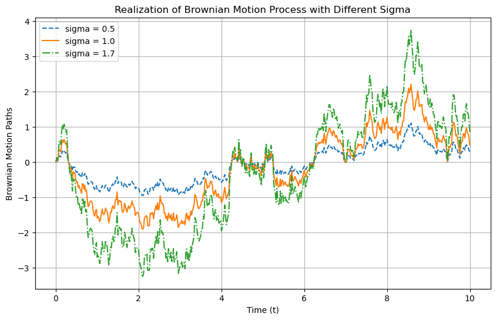

```python
# Plot the realizations
plt.figure(figsize=(10, 6))
plt.plot(t, W1, label='sigma = 0.5', linestyle='--')
plt.plot(t, W2, label='sigma = 1.0')
plt.plot(t, W3, label='sigma = 1.7', linestyle='-.')
plt.xlabel('Time (t)')
plt.ylabel('Brownian Motion Paths')
plt.title('Realization of Brownian Motion Process with Different Sigma')
plt.legend(loc='upper left')
plt.grid(True)
plt.show()
```

## Question 4

**Give a detailed relationship between a martingale and a filtration. How are the two useful in mathematical finance (3pts)**

## 4.1 Relationship between a Martingale and a Filtration

A **martingale** is a type of stochastic process that models a "fair game" in probability theory and mathematical finance. A martingale with respect to a filtration $\{ \Sigma_t \}$ is a stochastic process { X_t } on a filtered probability space $(\Omega, \Sigma, \{ \Sigma_t \}, P)$ that satisfies the following conditions:

1. **Adaptation**: The process { X_t } is adapted to the filtration $\{ \Sigma_t \}$, meaning that for each time $t$, $X_t$ is $\Sigma_t$-measurable.
2. **Integrability**: $E(|X_t|) < \infty$ for all $t \geq 0$.
3. **Martingale Property**: For all $s < t$, $E(X_t | \Sigma_s) = X_s$.

A **filtration** is a non-decreasing collection of $\sigma \text{-algebras}\ \{ \Sigma_t \}$ indexed by time $t$, representing the accumulation of information over time. Formally, a filtration satisfies $\Sigma_s \subseteq \Sigma_t$ for all $0 \leq s \leq t$. The filtration is said to be **natural** for a process $\{ X_t \}$ if it is generated by the process, i.e., $\Sigma_t = \sigma(X_s : 0 \leq s \leq t)$.

## 4.2 Usefulness in Mathematical Finance

In mathematical finance, martingales and filtrations are pivotal concepts, particularly in the modeling of asset prices and the pricing of financial derivatives. Here’s how they are useful:

1. **Pricing of Derivatives**: The martingale property is central to the concept of risk-neutral pricing. Under the risk-neutral measure, the discounted price of a financial asset should be a martingale. This ensures that there are no arbitrage opportunities, meaning that the expected future price of an asset, discounted back to the present value, equals its current price.
2. **Hedging**: Filtrations represent the flow of information over time, which is crucial for dynamic hedging strategies. Hedging strategies often rely on information up to the current time to make decisions, which is naturally modeled by processes adapted to a filtration.
3. **Risk Management**: Martingales are used in the computation of various risk measures, such as Value at Risk (VaR) and Expected Shortfall. They help in understanding the fair game property of asset returns, which is fundamental in managing financial risks.
4. **Stochastic Calculus**: Many results in stochastic calculus, such as Itô's lemma, are formulated in terms of martingales and filtrations. This branch of mathematics is widely used in the modeling of asset prices, interest rates, and other financial quantities.
5. **Efficient Market Hypothesis**: The concept of a martingale is related to the efficient market hypothesis, which states that asset prices fully reflect all available information. If markets are efficient, then price processes should follow a martingale with respect to the natural filtration generated by the market information.

## Question 5

**Give the statement of Ito’s lemma. Hence apply Ito’s Lemma to $f(Wt, t) = W^2_t$ (3pts)**

### 5.1 Ito’s Lemma

Ito’s Lemma is a fundamental result in stochastic calculus, providing the differential of a function of a stochastic process. The formal statement is as follows:

Let $X_t$ be an Ito process given by:

$ dX_t = \mu(X_t, t) dt + \sigma(X_t, t) dW_t $

where $\mu$ and $\sigma$ are functions of $X_t$ and $t$, and $W_t$ is a standard Brownian motion. If $f(X_t, t)$ is a twice continuously differentiable function, then $f(X_t, t)$ follows the SDE:

$ df(X_t, t) = \left( \frac{\partial f}{\partial t} + \mu \frac{\partial f}{\partial X} + \frac{1}{2} \sigma^2 \frac{\partial^2 f}{\partial X^2} \right) dt + \sigma \frac{\partial f}{\partial X} dW_t $

### 5.2 Applying Ito’s Lemma to $f(W_t, t) = W_t^2$

Given the function $f(W_t, t) = W_t^2$, $ W_t $ is a standard Brownian motion, so $ \mu(W_t, t) = 0 $ and $\sigma(W_t, t) = 1 $.

First, we compute the partial derivatives of $ f $:

$ f(W_t, t) = W_t^2 $

$ \frac{\partial f}{\partial t} = 0 $

$ \frac{\partial f}{\partial W_t} = 2W_t $

$ \frac{\partial^2 f}{\partial W_t^2} = 2 $

Now, substituting these into Ito’s Lemma:

$ df(W_t, t) = \left( 0 + 0 \cdot 2W_t + \frac{1}{2} \cdot 1^2 \cdot 2 \right) dt + 1 \cdot 2W_t dW_t $

Simplifying this:

$ df(W_t, t) = (1) dt + 2W_t dW_t $

Thus, the application of Ito's Lemma to $ f(W_t, t) = W_t^2 $ yields:

$ d(W_t^2) = dt + 2W_t dW_t $

Thus, the differential of $ W_t^2 $ using Ito’s Lemma is $ d(W_t^2) = dt + 2W_t dW_t $.

## Question 6

**Give a simulation of stock prices using Brownian motion in Python. Hence choose one of the parameters and explain the impact of varying it (4pts)**

### 6.1 Geometric Brownian Motion (GBM) Model

To simulate stock prices using Brownian motion, we can use the Geometric Brownian Motion (GBM) model, which is a common model for stock prices in mathematical finance. The GBM model for stock prices is given by:

$dS_t= \mu S_tdt+\sigma S_tdW_t$

where:

$S_t$ is the stock price at time $t$,

$\mu$ is the drift coefficient (mean return),

$\sigma$ is the volatility (standard deviation of returns),

$W_t$ is a standard Brownian motion.

To examine the impact of varying parameters, let's choose the volatility parameter $\sigma$ and explain its impact. We will simulate the stock price paths for different values of $\sigma$ while keeping the drift coefficient $\mu$ constant. The python code is as follows:

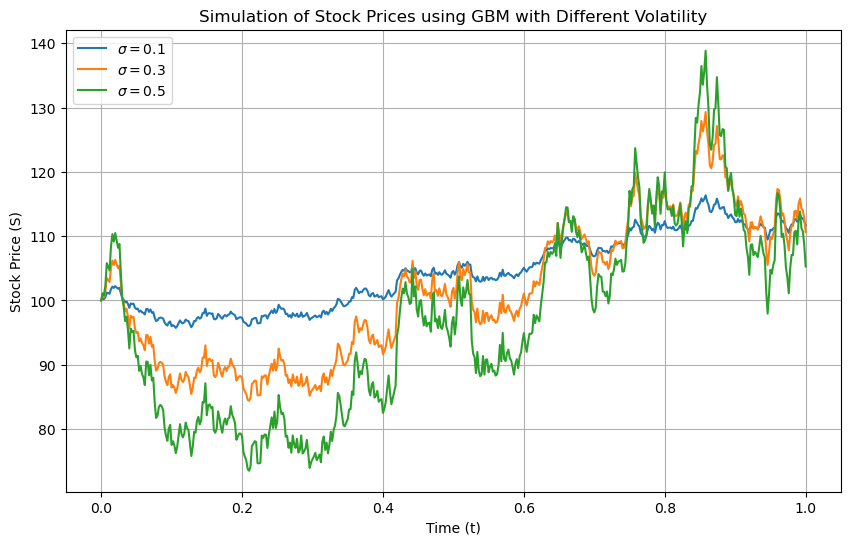

```python
##IMPORT NECESSARY LIBRARIES AND DEFINE PARAMETERS
# Libraries
import numpy as np
import matplotlib.pyplot as plt

# Parameters
T = 1.0  # total time (1 year)
N = 500  # number of time steps
dt = T/N  # time step size
t = np.linspace(0, T, N+1)  # time array
mu = 0.1  # drift coefficient (10% annual return)
S0 = 100  # initial stock price

# Different volatilities
sigmas = [0.1, 0.3, 0.5]


##GENERATE BROWNIAN MOTION PROCESS AND PLOT PATH
# Plot the stock price for different volatilities
plt.figure(figsize=(10, 6))

for sigma in sigmas:
    S = np.zeros(N+1)
    S[0] = S0
    np.random.seed(42)
    for i in range(1, N+1):
        dW = np.random.normal(0, np.sqrt(dt))
        S[i] = S[i-1] * np.exp((mu - 0.5 * sigma**2) * dt + sigma * dW)
    plt.plot(t, S, label=f'$\sigma={sigma}$')

plt.xlabel('Time (t)')
plt.ylabel('Stock Price (S)')
plt.title('Simulation of Stock Prices using GBM with Different Volatility')
plt.legend(loc='upper left')
plt.grid(True)
plt.show()
```